# Dropout

Dropout [1] is a technique for regularizing neural networks by randomly setting some features to zero during the forward pass. In this exercise you will implement a dropout layer and modify your fully-connected network to optionally use dropout.

[1] Geoffrey E. Hinton et al, "Improving neural networks by preventing co-adaptation of feature detectors", arXiv 2012

```python
# As usual, a bit of setup

import time
import numpy as np
import matplotlib.pyplot as plt
from fc_net import *
from data_utils import get_CIFAR10_data
from gradient_check import eval_numerical_gradient, eval_numerical_gradient_array
from solver import Solver

%matplotlib inline
plt.rcParams['figure.figsize'] = (10.0, 8.0) # set default size of plots
plt.rcParams['image.interpolation'] = 'nearest'
plt.rcParams['image.cmap'] = 'gray'

# for auto-reloading external modules
# see http://stackoverflow.com/questions/1907993/autoreload-of-modules-in-ipython
%load_ext autoreload
%autoreload 2

def rel_error(x, y):
  """ returns relative error """
  return np.max(np.abs(x - y) / (np.maximum(1e-8, np.abs(x) + np.abs(y))))
```

```python
# Load the (preprocessed) CIFAR10 data.

data = get_CIFAR10_data()
for k, v in data.iteritems():
  print '%s: ' % k, v.shape
```

```
X_val:  (1000, 3, 32, 32)
X_train:  (49000, 3, 32, 32)
X_test:  (1000, 3, 32, 32)
y_val:  (1000,)
y_train:  (49000,)
y_test:  (1000,)
```

# Dropout forward pass

In the file `layers.py`, implement the forward pass for dropout. Since dropout behaves differently during training and testing, make sure to implement the operation for both modes.

```
#### forward pass for example 3-layer neural network
def train_step(X,p):
  drop = 1 - p
  H1 = np.maximum(0, np.dot(theta1, X) + theta1_0)
  U1 = (np.random.rand(*H1.shape) < drop) / drop # first dropout mask. Notice /drop!
  H1 *= U1 # drop!
  H2 = np.maximum(0, np.dot(theta2, H1) + theta2_0)
  U2 = (np.random.rand(*H2.shape) < drop) / drop # second dropout mask. Notice /drop!
  H2 *= U2 # drop!
  out = np.dot(theta3, H2) + theta3_0
```

Once you have done so, run the cell below to test your implementation.

```python
x = np.random.randn(500, 500) + 10

for p in [0.3, 0.6, 0.75]:
  out, _ = dropout_forward(x, {'mode': 'train', 'p': p})
  out_test, _ = dropout_forward(x, {'mode': 'test', 'p': p})

  print 'Running tests with p = ', p
  print 'Mean of input: ', x.mean()
  print 'Mean of train-time output: ', out.mean()
  print 'Mean of test-time output: ', out_test.mean()
  print 'Fraction of train-time output set to zero: ', (out == 0).mean()
  print 'Fraction of test-time output set to zero: ', (out_test == 0).mean()
  print
```

```
Running tests with p =  0.3
Mean of input:  9.99975704885
Mean of train-time output:  10.0019121054
Mean of test-time output:  9.99975704885
Fraction of train-time output set to zero:  0.299856
Fraction of test-time output set to zero:  0.0

Running tests with p =  0.6
Mean of input:  9.99975704885
Mean of train-time output:  10.0144625909
Mean of test-time output:  9.99975704885
Fraction of train-time output set to zero:  0.59954
Fraction of test-time output set to zero:  0.0

Running tests with p =  0.75
Mean of input:  9.99975704885
Mean of train-time output:  9.97309830654
Mean of test-time output:  9.99975704885
Fraction of train-time output set to zero:  0.750632
Fraction of test-time output set to zero:  0.0
```

# Dropout backward pass

In the file `layers.py`, implement the backward pass for dropout. After doing so, run the following cell to numerically gradient-check your implementation.

```python
x = np.random.randn(10, 10) + 10
dout = np.random.randn(*x.shape)

dropout_param = {'mode': 'train', 'p': 0.8, 'seed': 123}
out, cache = dropout_forward(x, dropout_param)
dx = dropout_backward(dout, cache)
dx_num = eval_numerical_gradient_array(lambda xx: dropout_forward(xx, dropout_param)[0], x, dout)

print 'dx relative error: ', rel_error(dx, dx_num)
```

```
dx relative error:  1.89290647574e-11
```

# Fully-connected nets with Dropout

In the file `fc_net.py`, modify your implementation to use dropout. Specifically, if the constructor of the net receives a nonzero value for the `dropout` parameter, then the net should add dropout immediately after every ReLU nonlinearity. After doing so, run the following to numerically gradient-check your implementation.

```python
m, d, h1, h2, C = 2, 15, 20, 30, 10
X = np.random.randn(m, d)
y = np.random.randint(C, size=(m,))

for dropout in [0, 0.25, 0.5]:
  print 'Running check with dropout = ', dropout
  model = FullyConnectedNet([h1, h2], input_dim=d, num_classes=C,
                            weight_scale=5e-2, dtype=np.float64,
                            dropout=dropout, seed=123)

  loss, grads = model.loss(X, y)
  print 'Initial loss: ', loss

  for name in sorted(grads):
    f = lambda _: model.loss(X, y)[0]
    grad_num = eval_numerical_gradient(f, model.params[name], verbose=False, h=1e-5)
    print '%s relative error: %.2e' % (name, rel_error(grad_num, grads[name]))
  print
```

```
Running check with dropout =  0
Initial loss:  2.30304316117
theta1 relative error: 4.80e-07
theta1_0 relative error: 2.03e-08
theta2 relative error: 1.97e-07
theta2_0 relative error: 1.69e-09
theta3 relative error: 1.56e-07
theta3_0 relative error: 1.11e-10

Running check with dropout =  0.25
Initial loss:  2.298956181
theta1 relative error: 2.37e-08
theta1_0 relative error: 1.36e-09
theta2 relative error: 1.86e-07
theta2_0 relative error: 2.71e-09
theta3 relative error: 1.89e-08
theta3_0 relative error: 1.89e-10

Running check with dropout =  0.5
Initial loss:  2.30424261716
theta1 relative error: 1.21e-07
theta1_0 relative error: 2.28e-08
theta2 relative error: 2.45e-08
theta2_0 relative error: 6.84e-10
theta3 relative error: 8.06e-07
theta3_0 relative error: 1.28e-10
```

# Regularization experiment

As an experiment, we will train a pair of two-layer networks on 500 training examples: one will use no dropout, and one will use a dropout probability of 0.75. We will then visualize the training and validation accuracies of the two networks over time.

```python
# Train two identical nets, one with dropout and one without

num_train = 500
small_data = {
  'X_train': data['X_train'][:num_train],
  'y_train': data['y_train'][:num_train],
  'X_val': data['X_val'],
  'y_val': data['y_val'],
}

solvers = {}
dropout_choices = [0, 0.75]
for dropout in dropout_choices:
  model = FullyConnectedNet([500], dropout=dropout)
  print dropout

  solver = Solver(model, small_data,
                  num_epochs=25, batch_size=100,
                  update_rule='adam',
                  optim_config={
                    'learning_rate': 5e-4,
                  },
                  verbose=True, print_every=100)
  solver.train()
  solvers[dropout] = solver
```

```
0
(Iteration 1 / 125) loss: 8.596245
(Epoch 0 / 25) train acc: 0.224000; val_acc: 0.183000
(Epoch 1 / 25) train acc: 0.370000; val_acc: 0.227000
(Epoch 2 / 25) train acc: 0.560000; val_acc: 0.265000
(Epoch 3 / 25) train acc: 0.598000; val_acc: 0.278000
(Epoch 4 / 25) train acc: 0.692000; val_acc: 0.261000
(Epoch 5 / 25) train acc: 0.746000; val_acc: 0.267000
(Epoch 6 / 25) train acc: 0.812000; val_acc: 0.288000
(Epoch 7 / 25) train acc: 0.800000; val_acc: 0.268000
(Epoch 8 / 25) train acc: 0.884000; val_acc: 0.292000
(Epoch 9 / 25) train acc: 0.894000; val_acc: 0.287000
(Epoch 10 / 25) train acc: 0.906000; val_acc: 0.267000
(Epoch 11 / 25) train acc: 0.948000; val_acc: 0.285000
(Epoch 12 / 25) train acc: 0.958000; val_acc: 0.283000
(Epoch 13 / 25) train acc: 0.960000; val_acc: 0.291000
(Epoch 14 / 25) train acc: 0.972000; val_acc: 0.276000
(Epoch 15 / 25) train acc: 0.976000; val_acc: 0.276000
(Epoch 16 / 25) train acc: 0.986000; val_acc: 0.284000
(Epoch 17 / 25) train acc: 0.988000; val_acc: 0.294000
(Epoch 18 / 25) train acc: 0.988000; val_acc: 0.282000
(Epoch 19 / 25) train acc: 0.986000; val_acc: 0.287000
(Epoch 20 / 25) train acc: 0.980000; val_acc: 0.306000
(Iteration 101 / 125) loss: 0.033513
(Epoch 21 / 25) train acc: 0.988000; val_acc: 0.297000
(Epoch 22 / 25) train acc: 0.988000; val_acc: 0.305000
(Epoch 23 / 25) train acc: 0.992000; val_acc: 0.313000
(Epoch 24 / 25) train acc: 0.990000; val_acc: 0.300000
(Epoch 25 / 25) train acc: 0.988000; val_acc: 0.297000
0.75
(Iteration 1 / 125) loss: 17.295554
(Epoch 0 / 25) train acc: 0.230000; val_acc: 0.183000
(Epoch 1 / 25) train acc: 0.366000; val_acc: 0.267000
(Epoch 2 / 25) train acc: 0.450000; val_acc: 0.287000
(Epoch 3 / 25) train acc: 0.532000; val_acc: 0.288000
(Epoch 4 / 25) train acc: 0.560000; val_acc: 0.299000
(Epoch 5 / 25) train acc: 0.604000; val_acc: 0.305000
(Epoch 6 / 25) train acc: 0.614000; val_acc: 0.302000
(Epoch 7 / 25) train acc: 0.660000; val_acc: 0.288000
(Epoch 8 / 25) train acc: 0.740000; val_acc: 0.323000
(Epoch 9 / 25) train acc: 0.752000; val_acc: 0.307000
(Epoch 10 / 25) train acc: 0.778000; val_acc: 0.313000
(Epoch 11 / 25) train acc: 0.782000; val_acc: 0.338000
(Epoch 12 / 25) train acc: 0.790000; val_acc: 0.319000
(Epoch 13 / 25) train acc: 0.814000; val_acc: 0.306000
(Epoch 14 / 25) train acc: 0.840000; val_acc: 0.297000
(Epoch 15 / 25) train acc: 0.868000; val_acc: 0.302000
(Epoch 16 / 25) train acc: 0.876000; val_acc: 0.298000
(Epoch 17 / 25) train acc: 0.884000; val_acc: 0.305000
(Epoch 18 / 25) train acc: 0.900000; val_acc: 0.303000
(Epoch 19 / 25) train acc: 0.866000; val_acc: 0.294000
(Epoch 20 / 25) train acc: 0.890000; val_acc: 0.313000
(Iteration 101 / 125) loss: 8.652865
(Epoch 21 / 25) train acc: 0.908000; val_acc: 0.310000
(Epoch 22 / 25) train acc: 0.930000; val_acc: 0.308000
(Epoch 23 / 25) train acc: 0.942000; val_acc: 0.312000
(Epoch 24 / 25) train acc: 0.906000; val_acc: 0.312000
(Epoch 25 / 25) train acc: 0.912000; val_acc: 0.291000
```

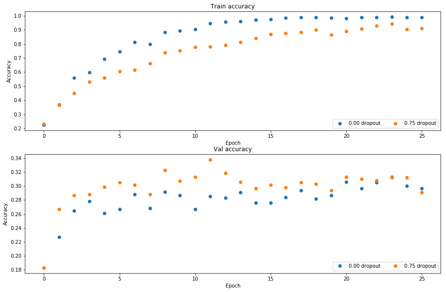

```python
# Plot train and validation accuracies of the two models

train_accs = []
val_accs = []
for dropout in dropout_choices:
  solver = solvers[dropout]
  train_accs.append(solver.train_acc_history[-1])
  val_accs.append(solver.val_acc_history[-1])

plt.subplot(3, 1, 1)
for dropout in dropout_choices:
  plt.plot(solvers[dropout].train_acc_history, 'o', label='%.2f dropout' % dropout)
plt.title('Train accuracy')
plt.xlabel('Epoch')
plt.ylabel('Accuracy')
plt.legend(ncol=2, loc='lower right')

plt.subplot(3, 1, 2)
for dropout in dropout_choices:
  plt.plot(solvers[dropout].val_acc_history, 'o', label='%.2f dropout' % dropout)
plt.title('Val accuracy')
plt.xlabel('Epoch')
plt.ylabel('Accuracy')
plt.legend(ncol=2, loc='lower right')

plt.gcf().set_size_inches(15, 15)
plt.show()
```